# Lab 9 - University Art Collection

Annie Hou

04/02 2024

### Load packages and data

```r
library(tidyverse)
library(skimr)
```

```r
art <- read_csv("data/art.csv")
```

### Exercise 9

Note that the warnings show that, since we are separating the titles, we expect to see two pieces of data. However, some rows had more than two pieces of data where only two were expected (e.g. row 29, 67, …) as they either have a range of years or additional parenthesis in the titles; and some rows had less than two pieces (e.g. row 6, 13, …) as they may contain no years in the titles. The additional pieces were discarded and the missing pieces were replaced by NAs.

It is fine for us becuase we only want to capture year where it’s convenient to do so. Now, rows with missing become NA, and additional rows are discarded, so the dataset now is still neat.

```r
# Remove eval = FALSE or set it to TRUE once data is ready to be loaded
art_cleaned <- art %>%
  separate(titles, into = c("title", "date"), sep = "\\(") %>%
  mutate(year = str_remove(date, "\\)") %>% as.numeric()) %>%
  select(title, artists, year, links)
```

```
## Warning: Expected 2 pieces. Additional pieces discarded in 45 rows [29, 67, 98, 228,
## 234, 243, 341, 431, 585, 639, 710, 738, 823, 971, 1152, 1412, 1435, 1675, 1808,
## 1929, ...].
```

```
## Warning: Expected 2 pieces. Missing pieces filled with `NA` in 723 rows [6, 13, 15, 25,
## 30, 31, 32, 34, 35, 37, 38, 40, 45, 48, 51, 59, 61, 71, 82, 83, ...].
```

### Exercise 10

```r
skimmed_summary <- skim(art_cleaned)
print(skimmed_summary)
```

```
## ── Data Summary ────────────────────────
##                            Values
## Name                       art_cleaned
## Number of rows             3275
## Number of columns          4
## _______________________
## Column type frequency:
##   character                3
##   numeric                  1
## ________________________
## Group variables            None
##
## ── Variable type: character ────────────────────────────────────────────────────
##   skim_variable n_missing complete_rate min max empty n_unique whitespace
## 1 title                 0         1       0  95     7     1606          0
## 2 artists             115         0.965   2 466     0     1203          0
## 3 links                 0         1      53  56     0     3275          0
##
## ── Variable type: numeric ──────────────────────────────────────────────────────
##   skim_variable n_missing complete_rate  mean   sd p0  p25  p50  p75 p100 hist
## 1 year               1571         0.520 1964. 53.6  2 1953 1962 1977 2020 ▁▁▁▁▇
```

### Exercise 11

Something out of the ordinary is that there are data points at zero. However, since we are plotting years, there shouldn’t be zeros.

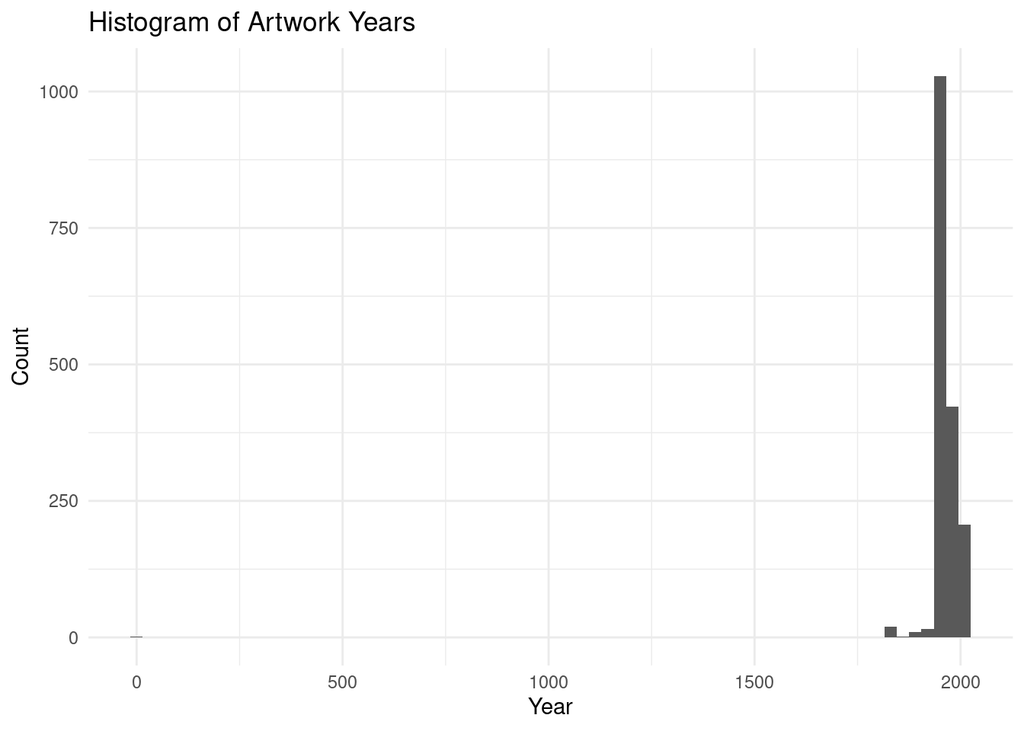

```r
ggplot(art_cleaned, aes(x = year)) +
  geom_histogram(binwidth = 30) +
  theme_minimal() +
  labs(x = "Year", y = "Count", title = "Histogram of Artwork Years")
```

### Exercise 12

By printting out the wrong year, we find that the wrong data entry is the art piece called Death Mask by H. Dempshall at year 2. Note that the year is wrong because there’s a (2) in the title, which is identified as the year, whereas the true year was discarded during separation as there are more than 2 pieces. The correct year would be 1964 by searching on the website.

```r
wrong_year <- art_cleaned %>%
  filter(year < 500)
print(wrong_year)
```

```
## # A tibble: 1 × 4
##   title         artists       year links
##   <chr>         <chr>        <dbl> <chr>
## 1 "Death Mask " H. Dempshall     2 https://collections.ed.ac.uk/record/21649?hi…
```

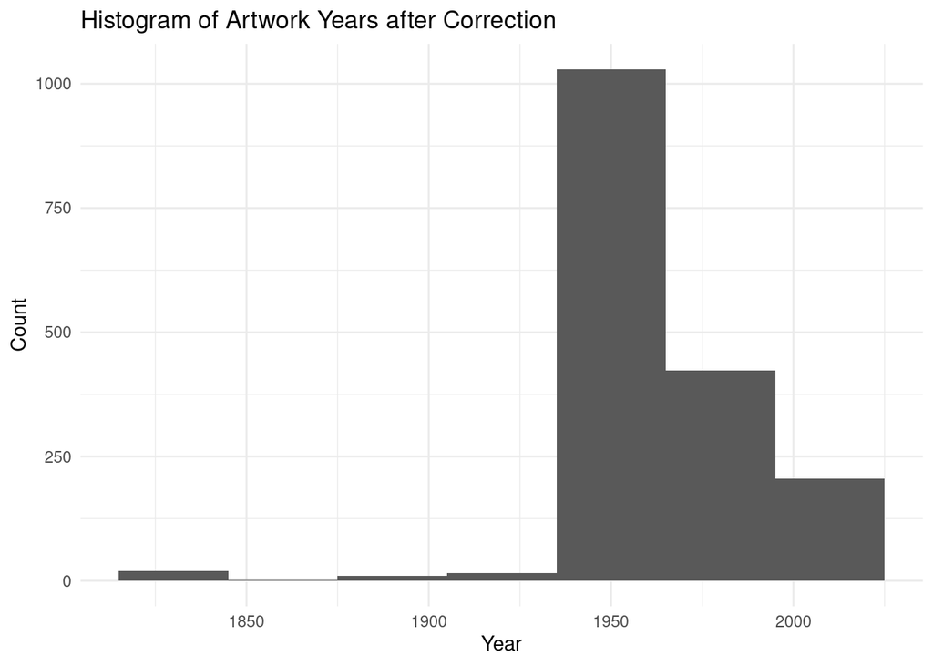

```r
# Modify to the correct year
correct_year = 1964
art_cleaned <- art_cleaned %>%
  mutate(year = case_when(
    year == 2 ~ correct_year,
    TRUE ~ year
  ))

# Replot the histogram
ggplot(art_cleaned, aes(x = year)) +
  geom_histogram(binwidth = 30) +
  theme_minimal() +
  labs(x = "Year", y = "Count", title = "Histogram of Artwork Years after Correction")
```

### Exercise 13

The most common artist is “unknown”, which appeared for 372 times.

```r
most_common_artist <- art_cleaned %>%
  count(artists, sort = TRUE) %>%
  filter(!is.na(artists)) %>%
  top_n(1)
print(most_common_artist)
```

```
## # A tibble: 1 × 2
##   artists     n
##   <chr>   <int>
## 1 Unknown   372
```

### Exercise 14

There are 11 art pieces have the word “child” in their title.

```r
library(stringr)

child_titles <- str_subset(tolower(art_cleaned$title), "child")
num = length(child_titles)
print(num)
```

```
## [1] 11
```